# Project 3 Exploratory Data Analysis

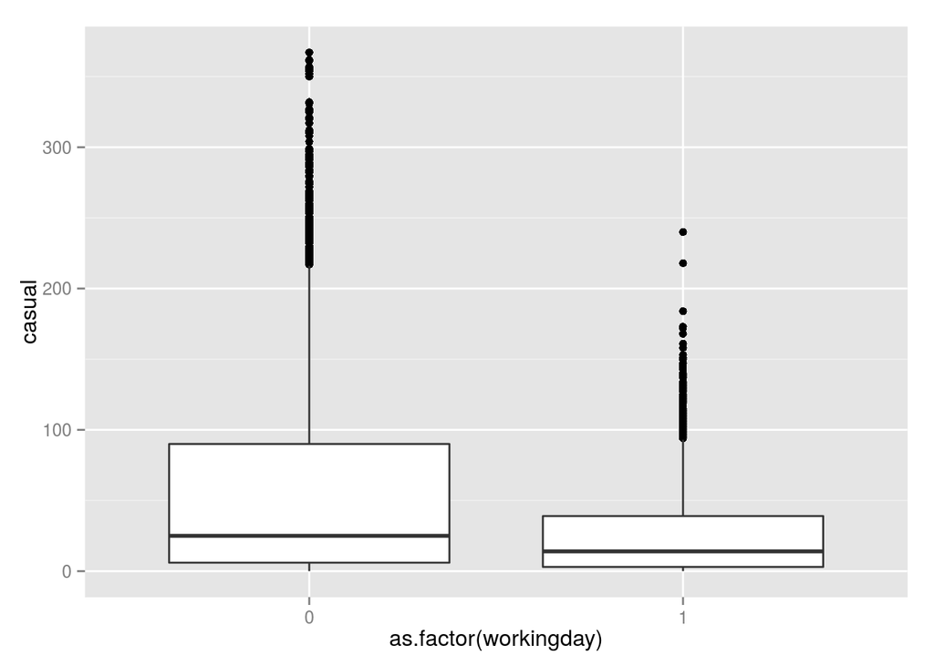

```r
ggplot(dts, aes(x=as.factor(workingday), y=casual)) + geom_boxplot()
```

Also the “workingday” influence is strong but totally different for the two types of rents.

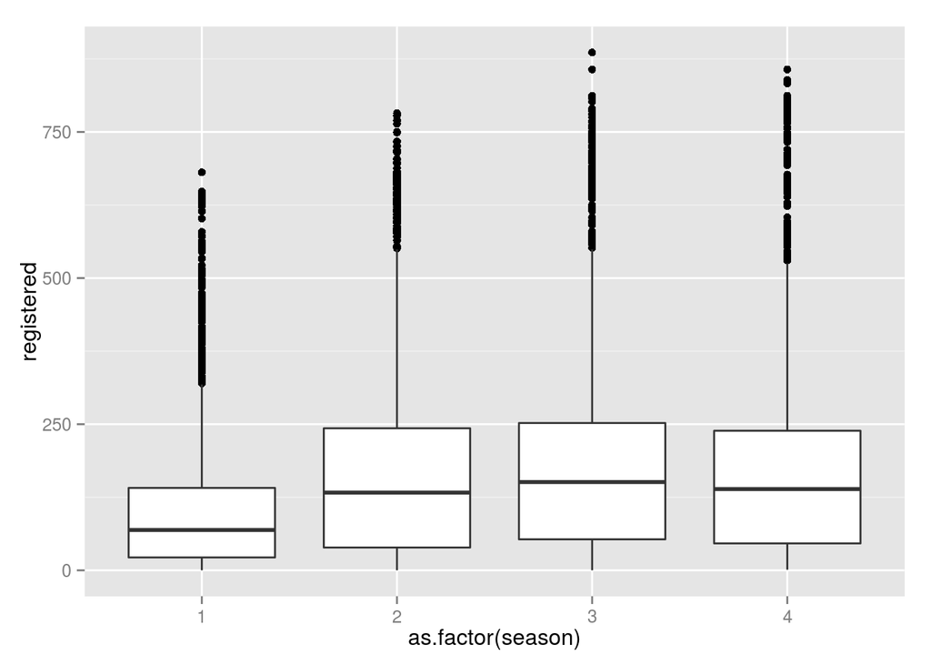

```r
ggplot(dts, aes(x=as.factor(season), y=registered)) + geom_boxplot()
```

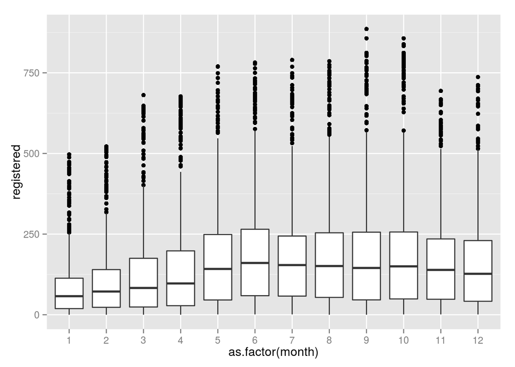

```r
ggplot(dts, aes(x=as.factor(month), y=registered)) + geom_boxplot()
```

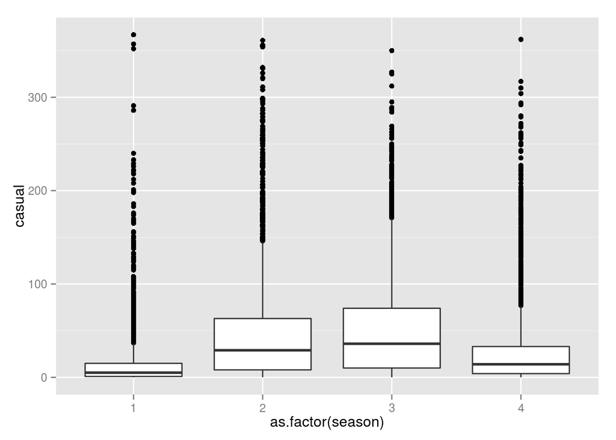

```r
ggplot(dts, aes(x=as.factor(season), y=casual)) + geom_boxplot()
```

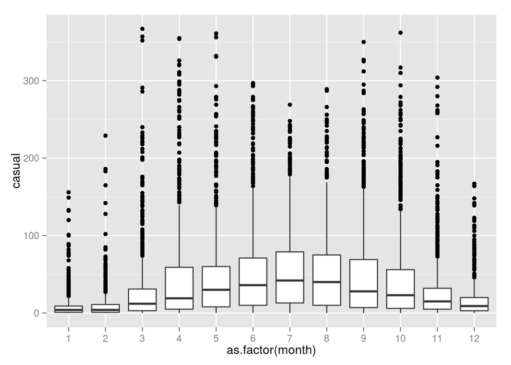

```r
ggplot(dts, aes(x=as.factor(month), y=casual)) + geom_boxplot()
```

The “month” and “season” features appear to be correlated to both the types of rents, and in the same way. I need to investigate more, but I think that “month” is in practice a repetition of the information about season.

## Bivariate analysis section

### Talk about some of the relationships you observed in this part of the investigation. How did the feature(s) of interest vary with other features in the dataset?

As expected temperature in season=1 is the coldest of the year, and season=3 is the hottest. Season=3 has the biggest count of sunny days, while season=1 is the most windy. The right labels are: winter label 1; summer label 3; spring label 2 and fall label 4.  
From climate-related features analysis emerges that:

- “temp” and “atemp” are strongly correlated each other, and have strong correlation to all the three response variables
- “weather” has a small correlation to the response variables, but the reason may be to the nature of this feature which is categorical.

From time-related features analysis emerges that:

- working day has a remarkable correlation to both registered and casual rentals, but the two correlation values have opposite sign.
- “hour” vs “registered” and “casual” show different behavior. Registered rentals show two sharp peaks while casual rentals show only one fat peak.

These behaviors seem reasonable: registered rentals are made by working people who probably need bike to go to work; on the contrary casual rentals are made by people during the week-end who decided at the end to go for a ride. So for registered rents, being a working day makes the rentals go higher (positive correlation), for casual rentals being a not-working day increases the rentals (negative correlation).  
“hour” feature correlation supports this hypothesis: registeredrentalsare made in working hours, the two peaks are at about 8 am and 6 pm; while for casualrentalsthe peak is the central hours of the day.

### Did you observe any interesting relationships between the other features (not the main feature(s) of interest)?

- unexpectedly “humidity” has a strong correlation with response variables, but more deep analysis is needed
- “humidity” and “weather” have remarkable correlation
- “windspeed” has very weak correlation to “registered”, but remarkable correlation to casual rentals
- “holiday” and “day” features have very low correlation to response variables
- “month” and “season” correlation to response variables are high but probably for the same reason, i.e. they are showing the same behavior of people influence by the period of the year.

### What was the strongest relationship you found?

The strongest correlation I saw is among “hour” of the day and rents. The linear model is not the most appropriate to explain the correlation: being at 01 or at 24 doesn’t change much the willingness of people to rent a bike. Using a non-linear transformation to “hour”, which counts, for example, for the time from and/or to the rush hours could increase the correlation to rentals count.

The numerous samples of rentals equal to very low values, make difficult to find a clear relation with the predictive variables.

## Multivariate plots section

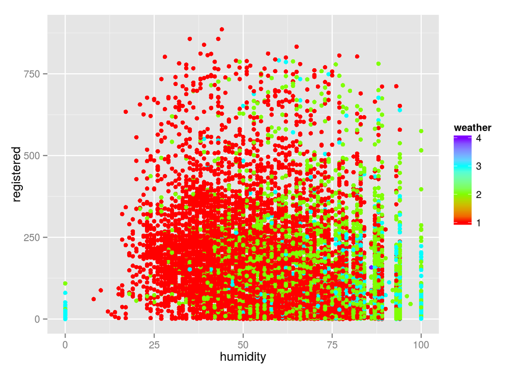

```r
ggplot(dts, aes(x=humidity, y=registered, color=weather)) + geom_point() + scale_colour_gradientn(colours=rainbow(4))
```

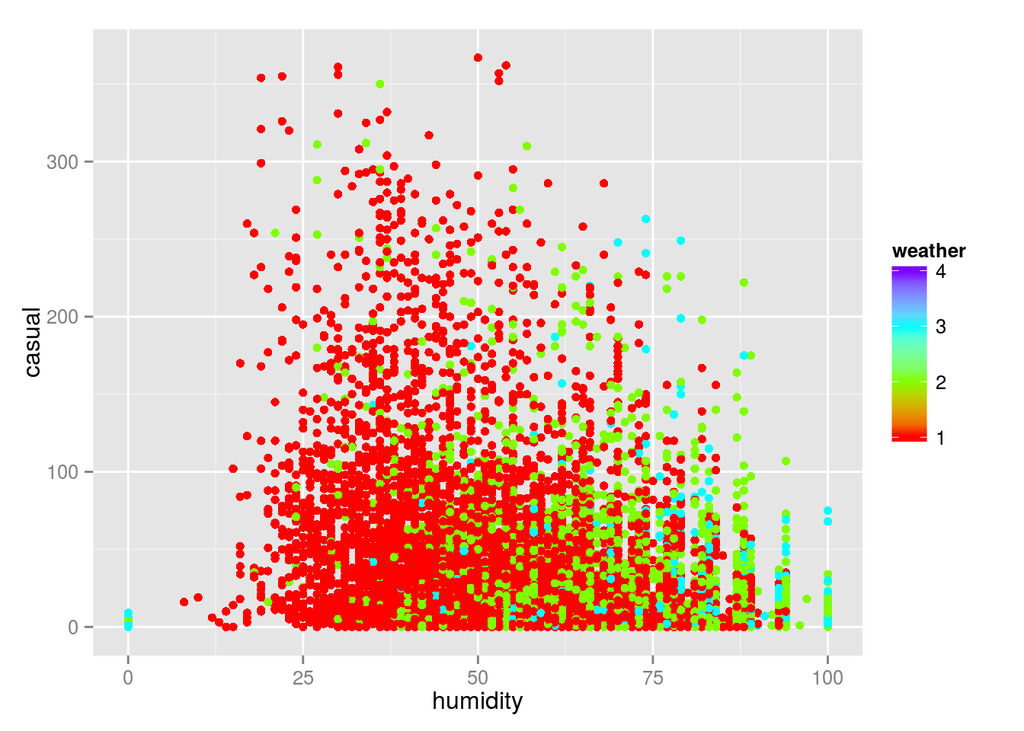

```r
ggplot(dts, aes(x=humidity, y=casual, color=weather)) + geom_point() + scale_colour_gradientn(colours=rainbow(4))
```

From these scatter plots it is hard to understand which of the two features, “weather” and “humidity”, is more influent to the response variables. Even though the relationship between weather and humidity is clear, the humidity increases as the weather gets worse, the relationship among weather and/or himidity to the response variable is not.

```r
library(Hmisc)
```

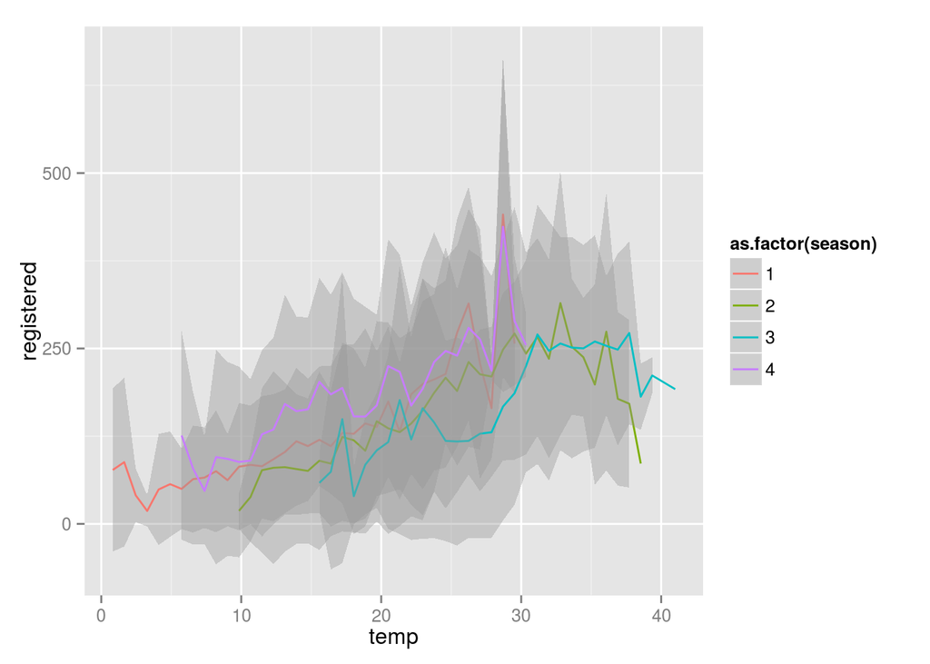

```r
ggplot(dts, aes(x=temp, y=registered, color=as.factor(season))) + stat_summary(fun.data ="mean_sdl", mult=1, geom = "smooth")
```

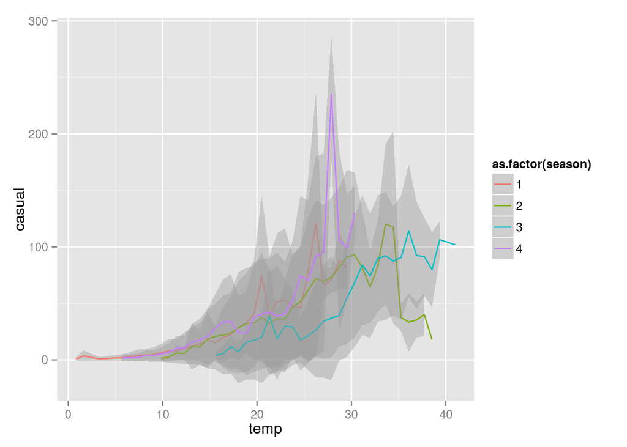

```r
ggplot(dts, aes(x=temp, y=casual, color=as.factor(season))) + stat_summary(fun.data ="mean_sdl", mult=1, geom = "smooth")
```

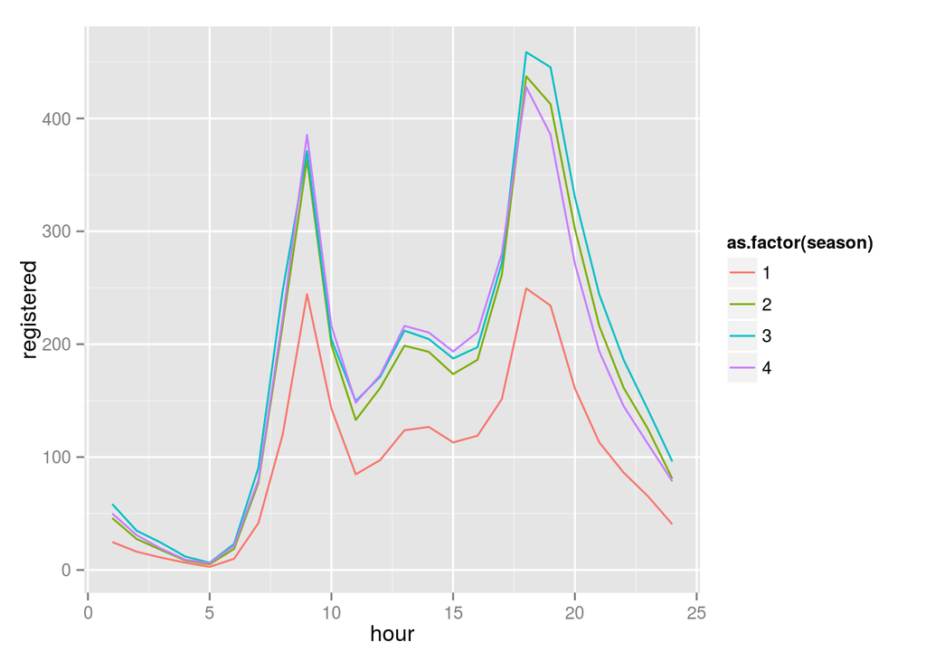

```r
ggplot(dts, aes(x=hour, y=registered, color=as.factor(season))) + geom_line(stat="summary", fun.y = mean)
```

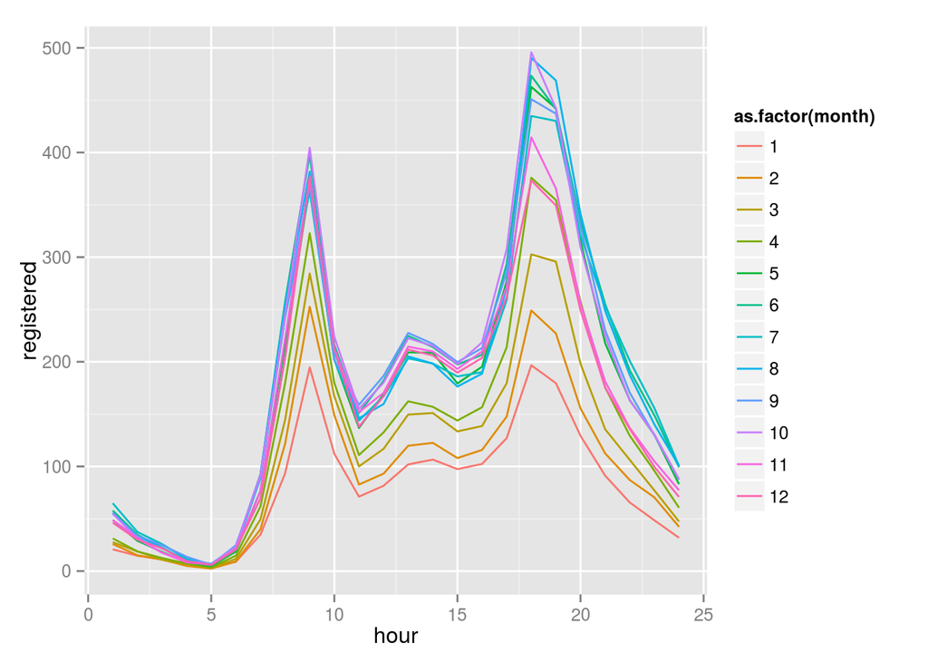

```r
ggplot(dts, aes(x=hour, y=registered, color=as.factor(month))) + geom_line(stat="summary", fun.y = mean)
```

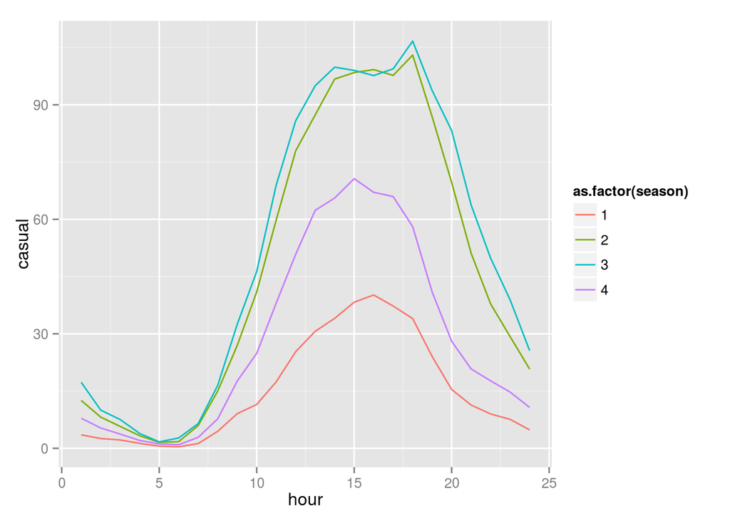

```r
ggplot(dts, aes(x=hour, y=casual, color=as.factor(season))) + geom_line(stat="summary", fun.y = mean)
```

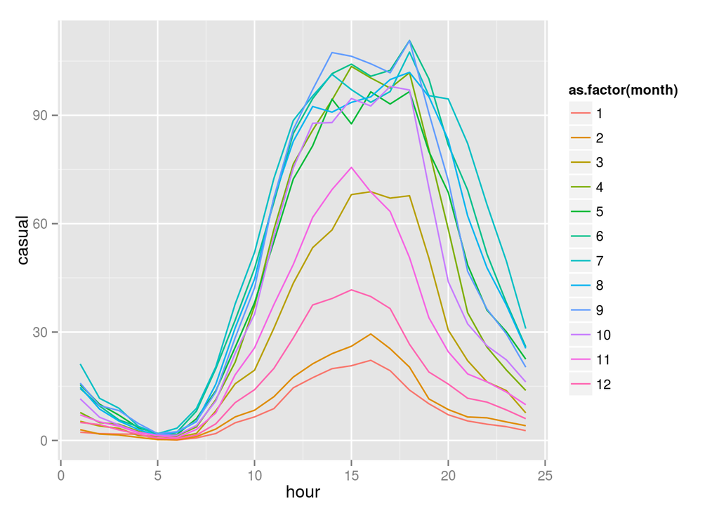

```r
ggplot(dts, aes(x=hour, y=casual, color=as.factor(month))) + geom_line(stat="summary", fun.y = mean)
```

As a matter of fact, “month” is not simply a repetition of “season” information, indeed the distributions of casual and registered rentals do not change based only on seasons; actually there are small changes also within the months of the same season. Hence, it would be more reasonable to remove “season” and add “month” to the predictive set.

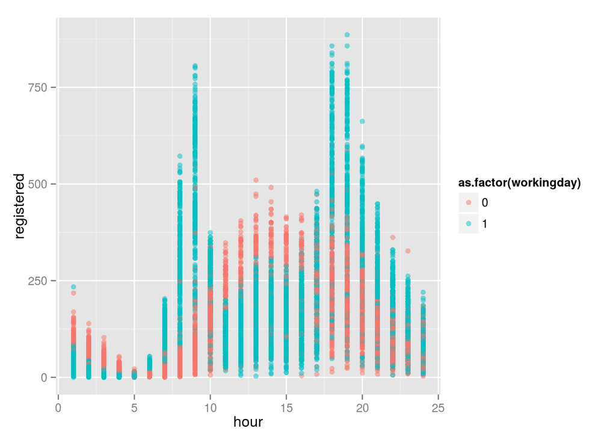

```r
ggplot(dts, aes(x=hour, y=registered, color=as.factor(workingday))) + geom_point(alpha=1/2)
```

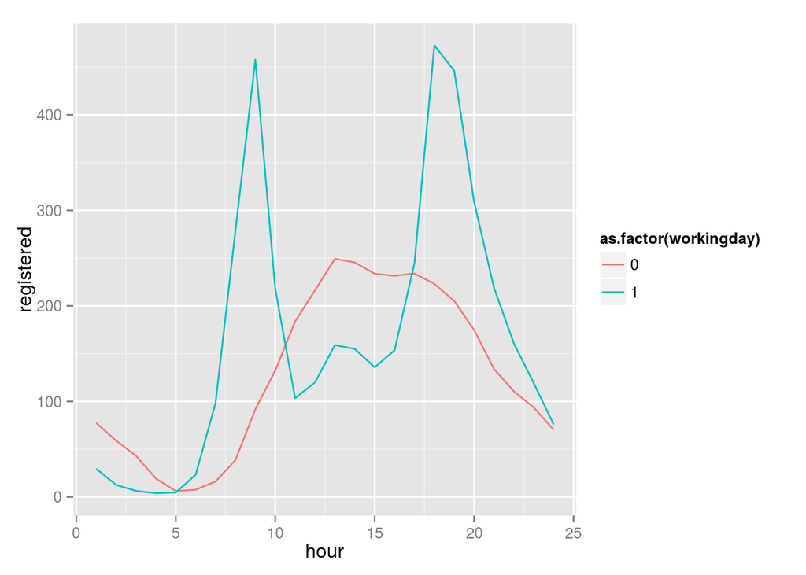

```r
ggplot(dts, aes(x=hour, y=registered, color=as.factor(workingday))) + geom_line(stat="summary", fun.y=mean)
```

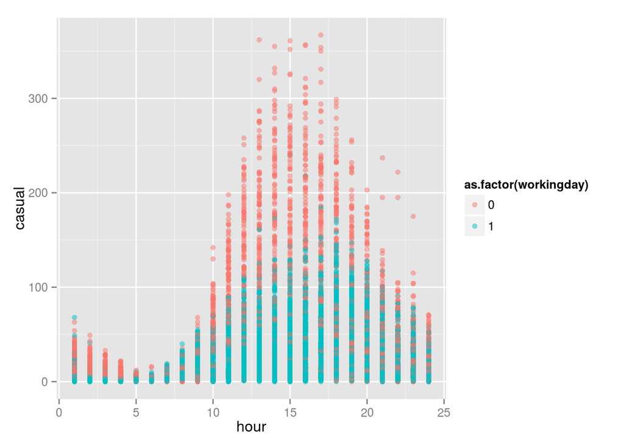

```r
ggplot(dts, aes(x=hour, y=casual, color=as.factor(workingday))) + geom_point(alpha=1/2)
```

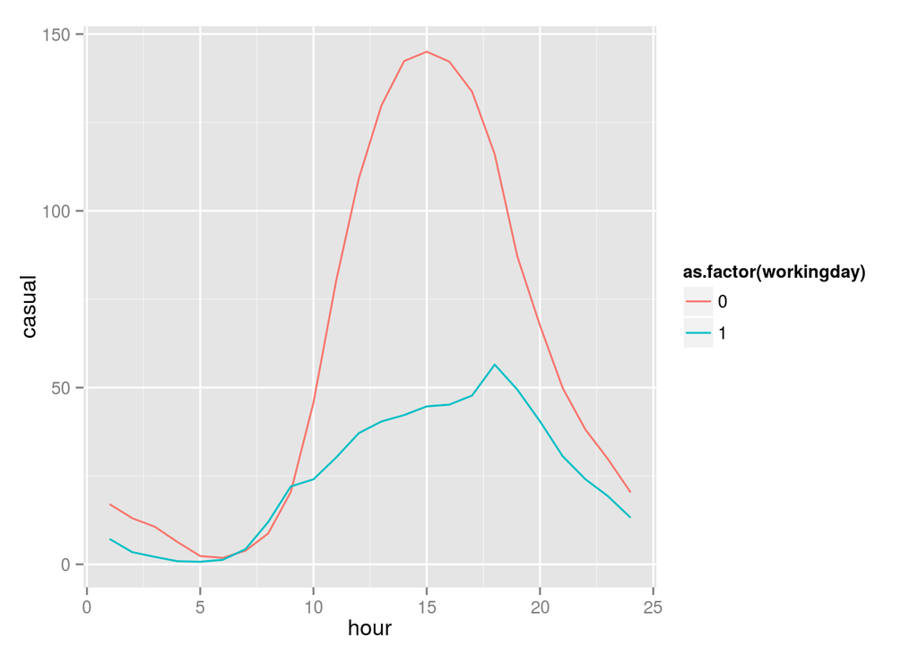

```r
ggplot(dts, aes(x=hour, y=casual, color=as.factor(workingday))) + geom_line(stat="summary", fun.y=mean)
```

Once more, response variables in function of “hour” depends whather the day is a working day or not.  
Now I’d like to investigate the behavior ofrentalsduring the year, in function of the hour.

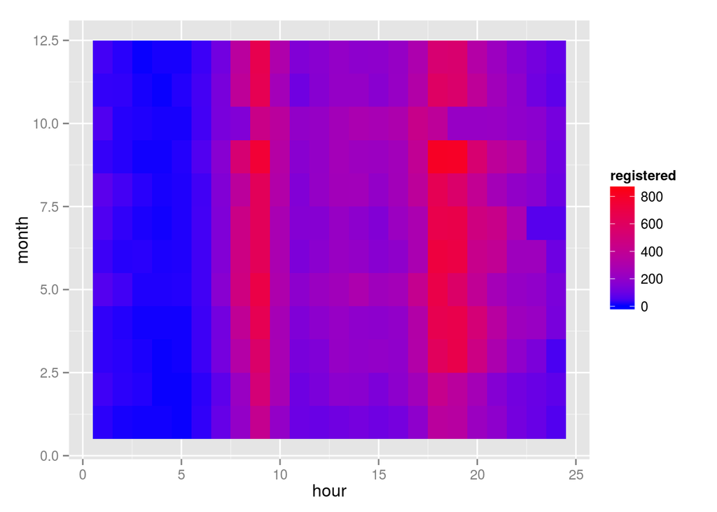

```r
ggplot(subset(dts, workingday==1), aes(x=hour, y=month, fill=registered)) + geom_tile() + scale_fill_gradient(low="blue", high="red")
```

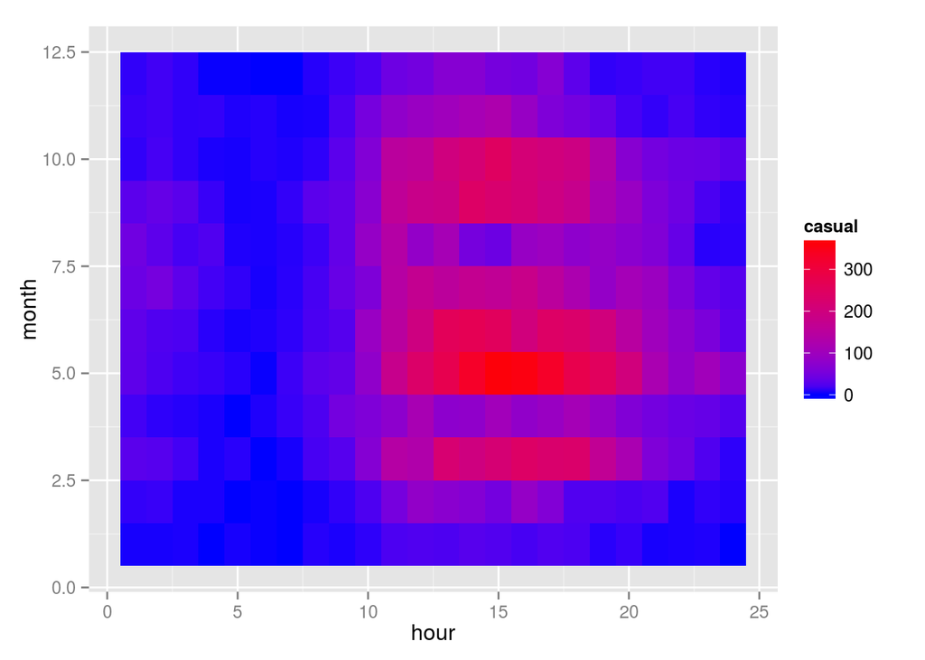

```r
ggplot(subset(dts, workingday==0), aes(x=hour, y=month, fill=casual)) + geom_tile() + scale_fill_gradient(low="blue", high="red")
```

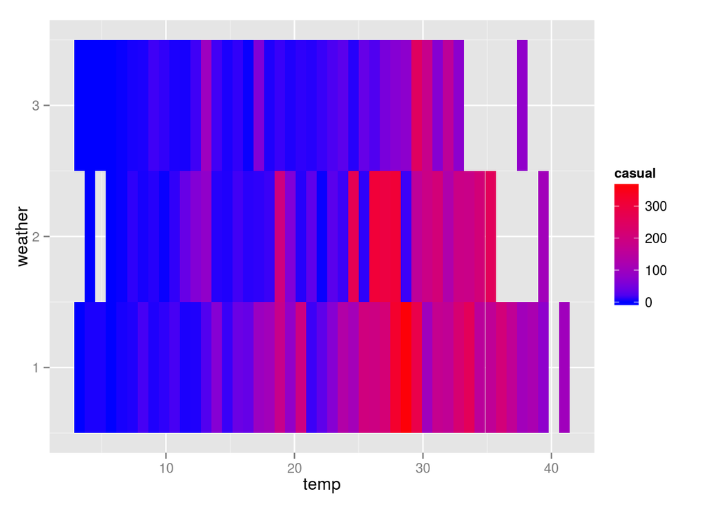

```r
ggplot(subset(dts, workingday==0), aes(x=temp, y=weather, fill=casual)) + geom_tile() + scale_fill_gradient(low="blue", high="red")
```

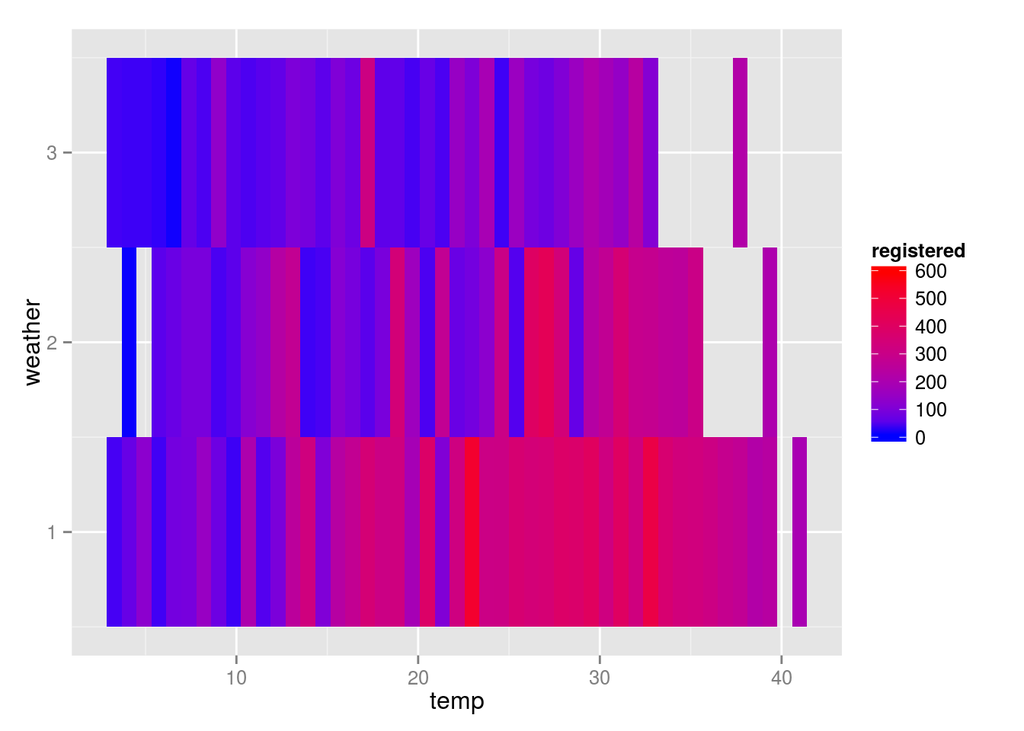

```r
ggplot(subset(dts, workingday==0), aes(x=temp, y=weather, fill=registered)) + geom_tile() + scale_fill_gradient(low="blue", high="red")
```

In this plots a specific zone, I called the “comfortable zone”, can be identfied in the lower right of the plot. In this zone, the number of riders is the highest. Note that the zone it’s not precisely the low right corner, but a bit more in the centre. Especially for casual rents, too high temperature it’s uncomfortable too. For “registered”, higher temperatures do not affect the number of rents as for “casual”; maybe because who decides to rent a bike in advance (registering) does not take into account temperatures but only weather.

## Multivariate analysis section

### Were there any interesting or surprising interactions between features?

Climate-related features, as expected, are more or less correlated each other and correlated to “season” index. “humidity” and “weather” are strongly correlated to each other; also “temp” and “atemp” are strongly correlated, the relation is almost deterministic.

## Final Plots and Summary

### Plot 1

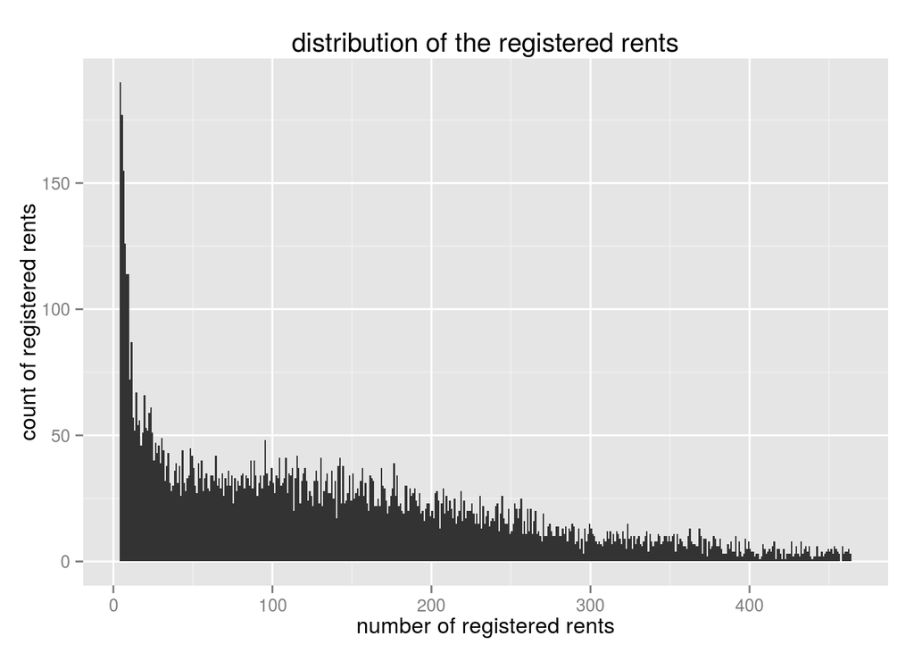

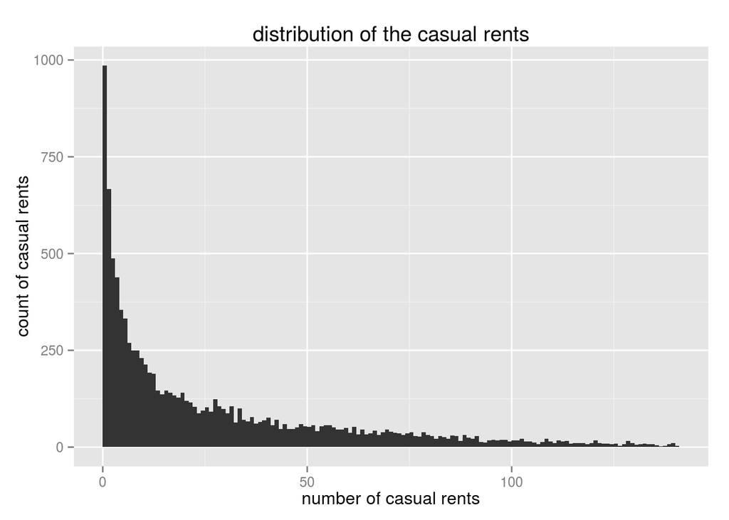

#### Description

The two distributions of registered and casual bike rentals are strongly skewed to zero. The problem resides in the dataset which, in my opinion, is too detailed. Some aggregation is needed to remove these zeros, while preserving the nature of the dataset and the phenomena it describes.

### Plot 2

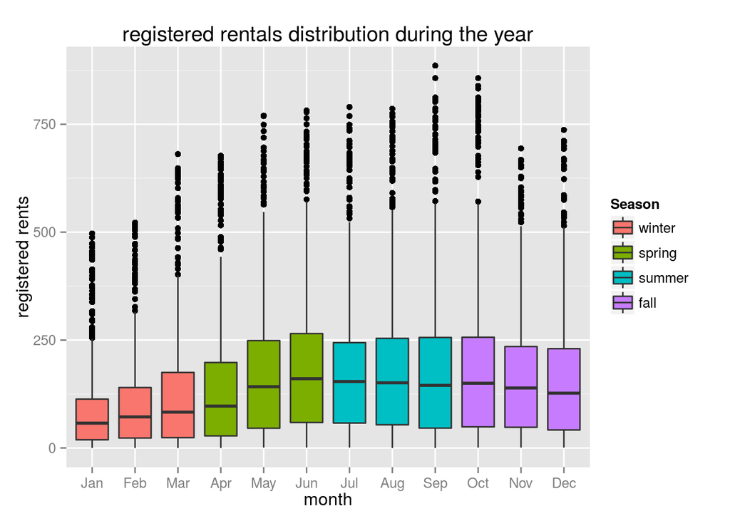

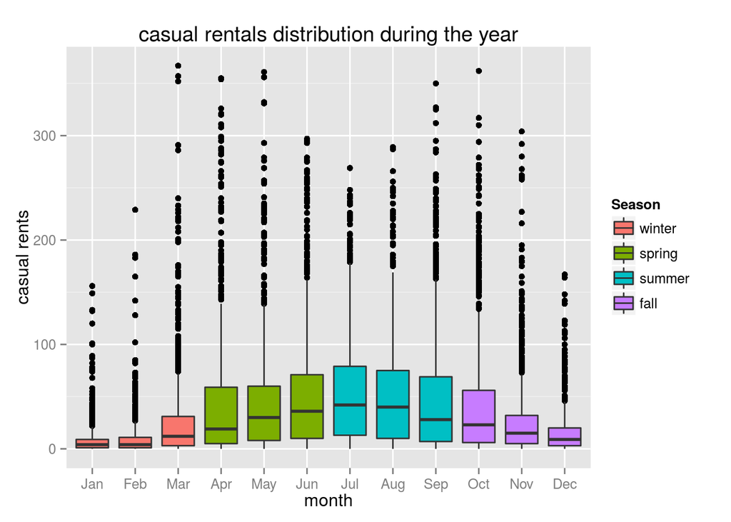

#### Description

The seasonal trend of rentals shown mounth by mounth. Casual rentals are driven, probably by tourism: the distribution is gaussian with a peak in July. The registered rentals are driven by resident people who uses the bike fo their trip during their everyday life; so the trend the count of registered rentals grow as spring starts, reaches the peak in June, slightly decreases in summer, and then decreases in fall months.

### Plot 3

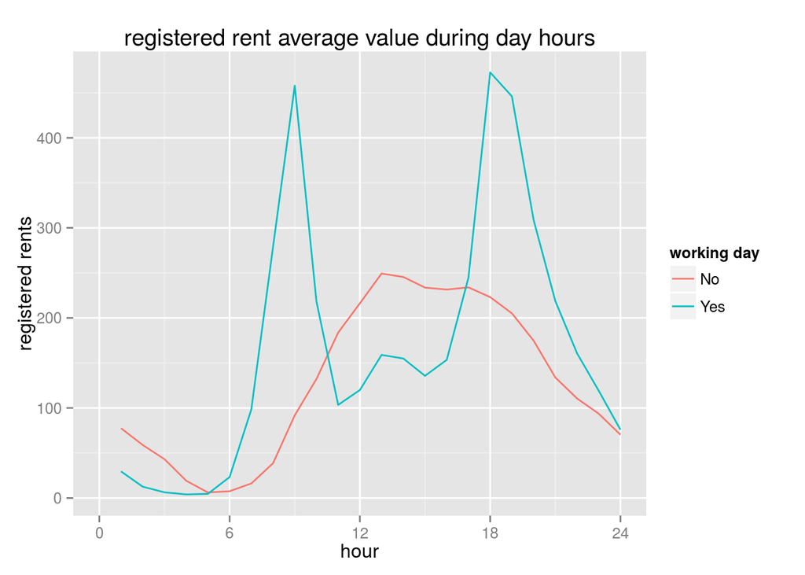

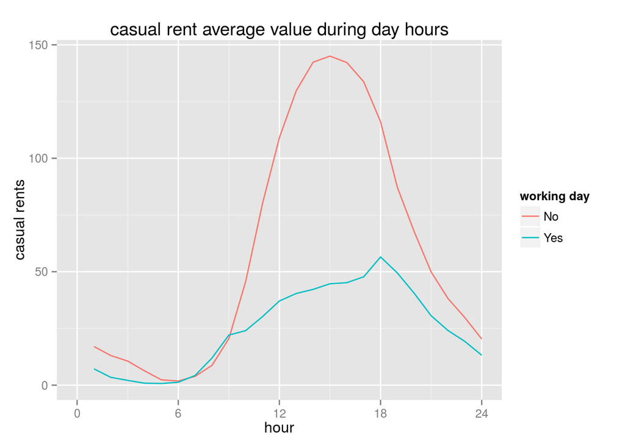

#### Description

Registered and casual rentals have totally different behaviors both in terms of hours of the day and whether the day is a working day or not. For registered rentals the biggest rent count happens during the rush hours of the working days. For casual rentals the peak is in the central hours of the non working days.

## Reflection

The Bike rental dataset is composed of 10886 rows with 11 features. The response features represents the number of rents, divided by the type of rent: “registered” rentals for users who registered their request, and “casual” rentals for users who just pick the pick the bike. The “count” feature (renamed in “total_rent”) simply represents the sum of the two. The predictive feature can be splitted in two sets: time-related features and climate-related features. Time-related features include: year month, day, hour and additional information like whether the day is a working day or holiday. Climate-related features include: humidity, temperature, windspeed and weather conditions.  
I started refactoring a bit the features to split information and represent them in a simpler and easier-to-use way. I started by exploring the variables one-by-one to understand the granularity of the dataset and the nature of the different variables. My first impression was that the dataset is very detailed: each row describe the situation in a single hour of a single day of the year. Of course with this level of detail, is is common to find dataset where variable that describes human-being activities counts lot of zero values.  
My first thought was that climate-related variables would be very useful to predict bike rents; the elementary deduction was that to have a bycicle ride you need nice and warm weather. At the same time I noticed that the provided features were too many and that maybe some kind of redundancy were present. I approached climate-related data to seek for the most valuable features to predict response variables by looking if some kind of linear relation exists among them.  
Unfortunatly I found that there is no strong relation, and that the weather and temperature conditions affects the variability of the rents. In case of bad weather or too cold or too hot temperatures, the rentals counts are pushed toward zero, but as the condition for a bike ride are good enough, the rentals do not assume precise or proportional value but, it happens that the variability of the rentals counts increases and the gap between minimum and maximum values incredibly increases.  
After these considerations, I started to think that probably the changes seen in climatic analysis were partially due to climate itself, but probably it was a consequence of the weather changes on due to seasons. My reasoning were right ans as shown in plot 2, months is the most significant feature to track changes in rentals beahavior on an year-based analysis.  
As last but not least I analyzed the rentals change within the days. I left this analyzed because I knew for sure that hour would be the most valid feature to predict rents. The analysis led to conclude that “registered” and “casual” rentals behave in totally different ways: the combination of “hour” and “workingday” shows that registered and casual rent counts are driven by people who have a totally different objective when renting a bike.  
Anyway, building a model to predict rentals would a lot more work. “hour” and “month” features should be reworked to represents in better way the human behavior. “month”, for example, should be substitued with a feature that describes the location of the month in seasons and within that season, as a decimal number for example. “hour” feature should be aggregate in bigger time slots to remove the many zero valued entries in rental counts.